# Luigi’s COVID-19 Data

Version: 3.0  
Created: 9/6/2023  
Last update: 01/11/2023

Analysis datasets and copy of the Rmd are in Rutgers box:  
https://rutgers.app.box.com/folder/227391194192

GitHub Repo:  
https://github.com/sargdavid/luigi_covid19

# Setup

```r
options(scipen=999)

require(data.table)
require(ggplot2)
require(table1)
require(DESeq2)

require(tidyverse)
require(tidytlg)
# require(gt)
# require(rtables)
require(gridExtra)
```

Javier, 9/15/2023:  
1. Build survival model using LOS as dates. Assuming all death are in-hospital, end of LOS.

Meeting 9/19/23:  
1. Was everybody admitted with COVID-19 symptoms? In Marshall’s email from 11/14/23 8:01AM he said “not sure [admission DX] will be necessary since admitting DX will be COVID”. Does this mean that controls where also admitted with COVID diagnoses? How?  
2. Do survival for in-patients only using LOS.  
3. Look at LOS of dead patients.  
4. Do DM patients have higher WHO OSCI score at admission?  
5. COVID+DM = more likely to go to ICU vs COVID+noDM? 6. Outcomes: death, LOS, ventilation, ICU.

Meeting 9/7/23:  
1. Look at inflammation signature w/wo DM, stratified by COVID.  
2. in COVID, coagulation cascade pathway was affected. See if we can find it in clin. data, ELIZA or RNA-seq. SHould coagulation be considered in COVID pateints’ treatment?  
3. Coding/non-coding gene co-expression.  
4. Activation of inflammatory pathways because we have transcriptome, not just genome.  
5. Neanderthals’ genes (see Lu’s email).  
6. Important factors: Critical care, WHO OSCI, LOS, ACE inhibitors, age>55, HTN, DM.

```r
# rows_empty <- function(mat) {
#   unlist(apply(mat, 1, function(x) !any(nzchar(x))), simplify = FALSE)
# }
#
# #' Emit a table as RTF via gentlg
# #' @inheritParams formatters::matrix_form
# tt_to_tbldf <- function(tt) {
#   mpf <- matrix_form(tt, indent_rownames = FALSE, expand_newlines = FALSE)
#   strmat <- mf_strings(mpf)
#   nhl <- mf_nlheader(mpf)
#   strbody <- strmat[-(1:nhl), , drop = FALSE]
#   row_type <- apply(strbody, 1,
#                     function(x) {
#                       nonempty <- nzchar(x)
#                       if(all(!nonempty)) { ## shouldn't ever happen
#                         "EMPTY"
#                       } else if (nonempty[1] && all(!nonempty[-1])) {# only 1st cell nonempty
#                         "HEADER"
#                       } else {
#                         if(x[1] == "N")
#                           "N"
#                         else
#                           "VALUE"
#                       }
#                     })
#   rowdf <- mf_rinfo(mpf)
#   rinds <- mf_lgrouping(mpf)[-(1:nhl)] - mf_nrheader(mpf)
#   indentme <- rowdf$indent[rinds]
#   anbr <- cumsum(!is.na(c(0, head(rowdf$trailing_sep, -1))))[rinds] + 1 ## so it starts at 1
#   roworder <- 1:NROW(rowdf) - (anbr - 1)
#   newrows <- c(0, ifelse(tail(anbr, -1) == head(anbr, -1), 0, 1))
#
#   tbldf <- as.data.frame(strbody)
#   names(tbldf) <- c("label", paste("col", seq(1, ncol(tbldf) - 1)))
#   cbind(tbldf, data.frame(row_type = row_type,
#                           anbr = anbr,
#                           indentme = indentme,
#                           roworder = roworder,
#                           newrows = newrows,
#                           stringsAsFactors = FALSE))
# }
#
# #' @rdname tt_to_tbldf
# #' @param file character(1). File path for output.
# tt_to_tlgrtf <- function(tt, file = "./table") {
#   df <- tt_to_tbldf(tt)
#   mpf <- matrix_form(tt, indent_rownames = FALSE, expand_newlines = FALSE)
#
#   strmat <- mf_strings(mpf)
#   nhl <- mf_nlheader(mpf)
#   nspancols <- nhl - 1L
#   if(nspancols > 0)
#     csph <- lapply(seq_len(nspancols), function(ii) strmat[ii,])
#   else
#     csph <- NULL
#   gentlg(df,
#          colspan = csph,
#          file = file,
#          colheader = strmat[nhl,],
#          title = main_title(tt),
#          footers = c(main_footer(tt), prov_footer(tt)))
# }
```

# Data

## Clinical variables and ELISA

```r
dt1 <- fread("Data/luigi_covid19_clinical_data.csv")
```

## Rename DX columns

```r
ndx <- which(colnames(dt1) %in% "Primary DX")
colnames(dt1)[ndx] <- paste0("diag",
                             1:length(ndx))
```

## Errata

Corrected as per Luigi’s emails

```r
dt1$COPD[dt1$COPD == 2] <- 1
dt1$RenalD[dt1$RenalD == 2] <- 1
dt1$COPD[dt1$COPD == 2] <- 1
dt1$`Full Dose Anticoagulation`[dt1$`Full Dose Anticoagulation` == 2] <- 1

dt1$`WHO-OSCI DISCHARGE`[dt1$`Real ID` %in% c("457084",
                                              "771982")] <- 8
```

# Endpoints

In-hospital death (Expired)  
30-day readmission  
90-day readmission  
30-day (out-of hospital?) mortality  
90-day (out-of hospital?) mortality

NOTE: last 4 only have data for non-COVID patients!  
2 additional patients died within 30days of discharge (is that correct?). I think it is from the discharge because 7215440 was admitted on 3/17/22, discharged on 5/2/22, and died “within 30 days” so cannot be from admission.

```r
dt1[dt1$`30 Day Mortality` == 1, ]
```

| Real ID | Whole Blood | Plasma | Study Group | Inpatient=1, ER=2, OP=3 | diag1 | diag2 | diag3 | diag4 | diag5 | diag6 | Admit Date | Discharge Date | 30 Day Readmission | 90 Day Readmission | 30 Day Mortality | 90 Day Mortality | Age | Sex | Race | Height (cm) | Weight (kg) | BMI | If BMI ?30 Obesity Class (I,II,III) | Vaccinated | Dose #1 | Dose #2 | Booster | Critical Care | ICU LOS | … |
| --- | --- | --- | --- | --- | --- | --- | --- | --- | --- | --- | --- | --- | --- | --- | --- | --- | --- | --- | --- | --- | --- | --- | --- | --- | --- | --- | --- | --- | --- | --- |
| 4840472 | NA | 0 | No COVID | Inpatient | J18.9 | R41.82 | J96.20 |  |  |  | 7/30/2022 | 8/4/2022 | 0 | 0 | 1 | 1 | 76 | Male | White Non-Hispanic | 167.6 | 56.0 | 19.94 | NA | 1 | 1 | 1 | 1 | 1 | 5 | … |
| 4932494 | NA | 1 | No COVID | Inpatient | R06.03 | R09.02 |  |  |  |  | 3/14/2022 | 3/24/2022 | 0 | 0 | 1 | 1 | 74 | Female | White Non-Hispanic | 162.6 | 73.1 | 27.65 | NA | NA | NA | NA | 9 | 1 | 9 | … |
| 4959911 | NA | 1 | No COVID | Inpatient | J18.9 |  |  |  |  |  | 3/12/2022 | 3/30/2022 | 0 | 0 | 1 | 1 | 86 | Male | White Non-Hispanic | 165.1 | 76.2 | 27.96 | NA | 1 | 1 | 1 | 1 | 0 | 0 | … |
| 5005559 | NA | 0 | No COVID | Inpatient | I24.9 |  |  |  |  |  | 7/27/2022 | 8/24/2022 | 1 | 1 | 1 | 1 | 83 | Male | White Non-Hispanic | 177.8 | 79.1 | 25.02 | NA | 1 | 1 | 1 | 1 | 1 | 4 | … |
| 7215440 | NA | 1 | No COVID | Inpatient | K56.609 | J96.92 |  |  |  |  | 3/17/2022 | 5/2/2022 | 0 | 0 | 1 | 1 | 74 | Female | White Non-Hispanic | 167.6 | 134.0 | 47.70 | III | 1 | 1 | 1 | 1 | 1 | 43 | … |

```r
dt1[, c("Study Group",
        # "Reason_for_Admission",
        "diag1",
        "DX1")]
```

| Study Group | diag1 | DX1 |
| --- | --- | --- |
| COVID |  | #N/A |
| COVID |  | #N/A |
| COVID |  | J18.9 |
| COVID |  | R06.02 |
| COVID |  | R09.02 |
| COVID |  | U07.1 |
| COVID |  | U07.1 |
| COVID |  | U07.1 |
| COVID |  | U07.1 |
| COVID |  | #N/A |

[output cut: 172 more lines]

### Remove unused columns

```r
dt1 <- data.table(`Real ID` = dt1$`Real ID`,
                  Reason_for_Admission = dt1$DX1,
                  dt1[, -1])

dt1$Reason_for_Admission[dt1$DX1 == ""] <- dt1$diag1[dt1$DX1 == ""]
dt1$Reason_for_Admission[dt1$Reason_for_Admission == "#N/A"] <- NA
```

### Fix Reason for Readmission

```r
dt1$Reason_for_Admission[dt1$`Study Group` == "COVID" &
                           is.na(dt1$Reason_for_Admission)] <- "U07.1"

dt1$Reason_for_Admission[dt1$Reason_for_Admission == "Pelvic Organ Prolapse/N81.9/N81.3"] <- "N81.9"
dt1$Reason_for_Admission[dt1$Reason_for_Admission == "Altered Mental Status/R41.82"] <- "R41.82"
dt1$Reason_for_Admission[dt1$Reason_for_Admission == "GI bleed/K92.2"] <- "K92.2"
dt1$Reason_for_Admission[dt1$Reason_for_Admission == "Hyperglycemia/R73.9"] <- "R73.9"
dt1$Reason_for_Admission[dt1$Reason_for_Admission == "RLQ Pain/R10. 31"] <- "R10.31"
dt1$Reason_for_Admission[dt1$Reason_for_Admission == "Altered Mental Status/R41.82"] <- "R41.82"
dt1$Reason_for_Admission[dt1$Reason_for_Admission == "N/A" ] <- NA
```

### Save DX1

```r
diags <- dt1[, .(N = .N),
             by = list(`Study Group`,
                       Reason_for_Admission)]

diags <- dcast.data.table(Reason_for_Admission ~ `Study Group`,
                          value.var = "N",
                          data = diags)

# diags <- dt1[, .(N = .N),
#              by = Reason_for_Admission]

write.csv(diags,
          file = "tmp/diags.csv",
          row.names = FALSE)

diags
```

| Reason_for_Admission | COVID | No COVID |
| --- | --- | --- |
| NA | NA | 1 |
| A41.89 | 1 | NA |
| A41.9 | NA | 1 |
| D50.9 | NA | 1 |
| D64.9 | NA | 1 |
| E16.2 | NA | 1 |
| E87.29 | NA | 1 |
| E87.5 | NA | 1 |
| F32.A | NA | 1 |
| G45.9 | NA | 1 |

[output cut: 53 more lines]

## Reason for admission

```r
# rfa <- fread("Data/diags_01112024_from_Vahe.csv")
rfa <- fread("Data/diags_01142024.csv")

rfa <- merge(dt1[, `Real ID`:`WHO-OSCI DISCHARGE`],
             rfa,
             by = "Reason_for_Admission",
             all.x = TRUE)

# dt1 <- merge(dt1,
#              rfa,
#              by = "Reason_for_Admission",
#              all.x = TRUE)

save(rfa,
     file = "tmp/rfa.RData")
```

### Delete DX columns

```r
dt1$diag1 <- NULL
dt1$diag2 <- NULL
dt1$diag3 <- NULL
dt1$diag4 <- NULL
dt1$diag5 <- NULL
dt1$diag6 <- NULL

dt1 <- dt1[, `Real ID`:`TNF beta`]
```

### Format clinical variables

```r
dt1$`Real ID` <- as.character(dt1$`Real ID`)

dt1$`Whole Blood` <- factor(dt1$`Whole Blood`,
                            levels = unique(dt1$`Whole Blood`))

dt1$Plasma <- factor(dt1$Plasma)

dt1$`Study Group` <- factor(dt1$`Study Group`,
                            levels = c("No COVID",
                                       "COVID"))

dt1$`Inpatient=1, ER=2, OP=3` <- factor(dt1$`Inpatient=1, ER=2, OP=3`,
                                        levels = c("Inpatient",
                                                   "ER",
                                                   "OP"))

dt1$`Admit Date` <- as.Date(as.character(dt1$`Admit Date`),
                            "%m/%d/%Y")

dt1$`Discharge Date` <- as.Date(as.character(dt1$`Discharge Date`),
                                "%m/%d/%Y")

dt1$Sex <- factor(dt1$Sex,
                  levels = c("Male",
                             "Female"))

dt1$Race <- factor(dt1$Race,
                   levels = c("White Non-Hispanic",
                              "Black",
                              "Asian",
                              "Hispanic",
                              "Other"))

dt1$`If BMI ?30 Obesity Class (I,II,III)` <- factor(dt1$`If BMI ?30 Obesity Class (I,II,III)`,
                                                    levels = c("I",
                                                               "II",
                                                               "III"))

dt1$Vaccinated <- factor(dt1$Vaccinated,
                         levels = c(0, 1),
                         labels = c("No",
                                    "Yes"))

dt1$`Dose #1` <- factor(dt1$`Dose #1`,
                        levels = c(0, 1),
                        labels = c("No",
                                   "Yes"))

dt1$`Dose #2` <- factor(dt1$`Dose #2`,
                        levels = c(0, 1),
                        labels = c("No",
                                   "Yes"))

dt1$Booster <- factor(dt1$Booster,
                      levels = c(0, 1, 9),
                      labels = c("No",
                                 "Yes",
                                 "Unknown"))

dt1$`Critical Care` <- factor(dt1$`Critical Care`,
                              levels = c(0, 1),
                              labels = c("No",
                                         "Yes"))

# `ICU LOS` = length of stay in the hospital
dt1$Still_In_Hospital_08182023 <- is.na(as.numeric(dt1$`ICU LOS`))
dt1$`ICU LOS` <- as.numeric(dt1$`ICU LOS`)

# Death
dt1$Expired <- factor(dt1$Expired,
                      levels = c(0, 1),
                              labels = c("No",
                                         "Yes"))

dt1$Wave <- factor(dt1$Wave,
                   levels = c(1:4))

# Luigi's keys
dt1$`Smoking History (0,1,2)` <- factor(dt1$`Smoking History (0,1,2)`,
                                        levels = c("Current",
                                                   "Former",
                                                   "Never"))

# !!! GET LABELS!!!
dt1$Age_Category <- factor(dt1$Age_Category,
                           levels = 0:4)

# Co-diagnoses/pre-existing conditions
dt1$MI <- factor(dt1$MI)
dt1$HF <- factor(dt1$HF)
dt1$PVD <- factor(dt1$PVD)
dt1$CVD <- factor(dt1$CVD)
dt1$Dementia <- factor(dt1$Dementia)
dt1$COPD <- factor(dt1$COPD)
dt1$`Rheum/ CONNECTIVE TISSUE DISEASE` <- factor(dt1$`Rheum/ CONNECTIVE TISSUE DISEASE`)
dt1$PUD <- factor(dt1$PUD)
dt1$mliverd <- factor(dt1$mliverd)
dt1$DiabNC <- factor(dt1$DiabNC)
dt1$DiabC <- factor(dt1$DiabNC)
dt1$AnyDM <- factor(dt1$AnyDM)
dt1$Hemoplegia <- factor(dt1$Hemoplegia)
dt1$RenalD <- factor(dt1$RenalD)
dt1$Cancer <- factor(dt1$Cancer)
dt1$msliver <- factor(dt1$msliver)
dt1$MetaCancer <- factor(dt1$MetaCancer)
dt1$AIDS <- factor(dt1$AIDS)
dt1$HTN <- factor(dt1$HTN)
dt1$Obese <- factor(dt1$Obese)

# Medications
dt1$tocilizumab <- factor(dt1$tocilizumab)
dt1$remdesivir <- factor(dt1$remdesivir)
dt1$dexamethasone <- factor(dt1$dexamethasone)
dt1$methylprednisolone <- factor(dt1$methylprednisolone)
dt1$prednisone <- factor(dt1$prednisone)
dt1$hydrocortisone <- factor(dt1$hydrocortisone)
dt1$azithromycin <- factor(dt1$azithromycin)
dt1$hydroxychloroquine <- factor(dt1$hydroxychloroquine)
dt1$regeneron <- factor(dt1$regeneron)
dt1$ACEis <- factor(dt1$ACEis)
dt1$ARBs <- factor(dt1$ARBs)
dt1$ARNIs <- factor(dt1$ARNIs)
dt1$Insulin <- factor(dt1$Insulin)
dt1$Metformin <- factor(dt1$Metformin)
dt1$Glimepiride <- factor(dt1$Glimepiride)
dt1$Glipizide <- factor(dt1$Glipizide)
dt1$Sitagliptin <- factor(dt1$Sitagliptin)
dt1$`Full Dose Anticoagulation` <- factor(dt1$`Full Dose Anticoagulation`)
dt1$`Prophylactic Anticoagulation` <- factor(dt1$`Prophylactic Anticoagulation`)

# Lab work
## NOTE: set correct values for LOQ/LOD! Converted to NAs for now
dt1$HbA1c <- as.numeric(dt1$HbA1c)
dt1$Vit_D_level <- as.numeric(dt1$Vit_D_level)
dt1$ALT <- as.numeric(dt1$ALT)
dt1$AST <- as.numeric(dt1$AST)
dt1$`hs-CRP` <- as.numeric(dt1$`hs-CRP`)
dt1$CRP <- as.numeric(dt1$CRP)
dt1$Fibrinogen <- as.numeric(dt1$Fibrinogen)
dt1$`D-Dimer` <- as.numeric(dt1$`D-Dimer`)
dt1$ESR <- as.numeric(dt1$ESR)
dt1$Ferritin <- as.numeric(dt1$Ferritin)
dt1$LDH <- as.numeric(dt1$LDH)
dt1$`Lactic Acid` <- as.numeric(dt1$`Lactic Acid`)
dt1$PCT <- as.numeric(dt1$PCT)
dt1$`Glucose Lvl` <- as.numeric(dt1$`Glucose Lvl`)
dt1$Screat <- as.numeric(dt1$Screat)

# Diagnoses
dt1$Hyperlipidemia <- factor(dt1$Hyperlipidemia)
dt1$`# Metabolic Syndrome Criteria` <- factor(dt1$`# Metabolic Syndrome Criteria`)

# NA should be non-COVID patients - CHECK
dt1$`WHO-OSCI D1` <- factor(dt1$`WHO-OSCI D1`,
                            levels = 0:7)
dt1$`WHO-OSCI D3` <- factor(dt1$`WHO-OSCI D3`,
                            levels = 0:7)
dt1$`WHO-OSCI D7` <- factor(dt1$`WHO-OSCI D7`,
                            levels = 0:7)
dt1$`WHO-OSCI D14` <- factor(dt1$`WHO-OSCI D14`,
                             levels = 0:7)
dt1$`WHO-OSCI D21` <- factor(dt1$`WHO-OSCI D21`,
                             levels = 0:7)
dt1$`WHO-OSCI D28` <- factor(dt1$`WHO-OSCI D28`,
                             levels = 0:7)

dt1$`WHO-OSCI DISCHARGE` <- factor(dt1$`WHO-OSCI DISCHARGE`)

# ELISA: all numeric
```

### Summary clinical and ELISA

```r
summary(dt1)
```

```
   Real ID          Reason_for_Admission               Whole Blood Plasma   Study Group
 Length:182         Length:182           Whole Blood         :62   0:84   No COVID: 72
 Class :character   Class :character     Whole Blood + Trizol:48   1:98   COVID   :110
 Mode  :character   Mode  :character     NA's                :72




 Inpatient=1, ER=2, OP=3   Admit Date         Discharge Date       30 Day Readmission
 Inpatient:164           Min.   :2020-04-13   Min.   :2020-04-19   Min.   :0.0000
 ER       : 13           1st Qu.:2020-12-01   1st Qu.:2020-12-05   1st Qu.:0.0000
 OP       :  5           Median :2021-03-30   Median :2021-04-02   Median :0.0000
                         Mean   :2021-08-07   Mean   :2021-08-06   Mean   :0.2361
                         3rd Qu.:2022-03-22   3rd Qu.:2022-03-29   3rd Qu.:0.0000
                         Max.   :2023-08-01   Max.   :2023-08-03   Max.   :1.0000
                         NA's   :28           NA's   :34           NA's   :110
 90 Day Readmission 30 Day Mortality  90 Day Mortality       Age            Sex
 Min.   :0.0000     Min.   :0.00000   Min.   :0.00000   Min.   :21.00   Male  :100
 1st Qu.:0.0000     1st Qu.:0.00000   1st Qu.:0.00000   1st Qu.:55.00   Female: 82
 Median :0.0000     Median :0.00000   Median :0.00000   Median :65.50
 Mean   :0.3611     Mean   :0.06944   Mean   :0.06944   Mean   :64.28
 3rd Qu.:1.0000     3rd Qu.:0.00000   3rd Qu.:0.00000   3rd Qu.:77.00
 Max.   :1.0000     Max.   :1.00000   Max.   :1.00000   Max.   :94.00
 NA's   :110        NA's   :110       NA's   :110
                 Race      Height (cm)     Weight (kg)          BMI
 White Non-Hispanic:117   Min.   :142.2   Min.   : 42.00   Min.   :16.66
 Black             : 14   1st Qu.:162.6   1st Qu.: 68.95   1st Qu.:24.67
 Asian             : 26   Median :167.6   Median : 84.50   Median :29.10
 Hispanic          : 16   Mean   :168.9   Mean   : 87.22   Mean   :30.43
 Other             :  9   3rd Qu.:177.2   3rd Qu.: 99.10   3rd Qu.:33.78
                          Max.   :198.1   Max.   :217.00   Max.   :71.63

 If BMI ?30 Obesity Class (I,II,III) Vaccinated Dose #1    Dose #2       Booster
 I   : 43                            No  :101   No  :102   No  :121   No     :135
 II  : 22                            Yes : 73   Yes : 72   Yes : 49   Yes    : 33
 III : 16                            NA's:  8   NA's:  8   NA's: 12   Unknown: 14
 NA's:101



```

[output cut: 113 more lines]

```
 Min.   :  0.000   Min.   :  0.00   Min.   : 0.0000    Min.   : 0.000    Min.   :0.000
 1st Qu.:  8.182   1st Qu.: 13.38   1st Qu.: 0.0000    1st Qu.: 0.000    1st Qu.:0.590
 Median : 14.620   Median : 24.58   Median : 0.0375    Median : 3.833    Median :0.945
 Mean   : 21.732   Mean   : 35.61   Mean   : 0.9178    Mean   :12.228    Mean   :1.385
 3rd Qu.: 27.901   3rd Qu.: 49.71   3rd Qu.: 0.7538    3rd Qu.:14.795    3rd Qu.:1.731
 Max.   :113.880   Max.   :199.57   Max.   :11.1500    Max.   :70.140    Max.   :9.005
 NA's   :60        NA's   :60       NA's   :60         NA's   :60        NA's   :60
    TNF beta        Still_In_Hospital_08182023
 Min.   : 0.00000   Mode :logical
 1st Qu.: 0.00000   FALSE:182
 Median : 0.00000
 Mean   : 0.54102
 3rd Qu.: 0.04375
 Max.   :10.00500
 NA's   :60
```

## Gene expressions

NOTE: data contains both, coding and non-coding genes.

### First RNA-seq file

```r
dt2 <- fread("Data/gene_count.xls")

rnaseq_meta1 <- data.table(sample_names = colnames(dt2)[2:58],
                           rnaseq_cohort = sapply(strsplit(x = colnames(dt2)[2:58],
                                                           split = "_"),
                                                  function(x) x[1]),
                           `Real ID` = sapply(strsplit(x = colnames(dt2)[2:58],
                                                       split = "_"),
                                              function(x) x[2]))
rnaseq_meta1
```

| sample_names | rnaseq_cohort | Real ID |
| --- | --- | --- |
| cov_464811 | cov | 464811 |
| cov_8132930 | cov | 8132930 |
| cov_375729 | cov | 375729 |
| cov_465716 | cov | 465716 |
| cov_8133450 | cov | 8133450 |
| cov_652640 | cov | 652640 |
| cov_8134377 | cov | 8134377 |
| cov_8134403 | cov | 8134403 |
| cov_659302 | cov | 659302 |
| cov_8133455 | cov | 8133455 |

[output cut: 47 more lines]

### Second RNA-seq file

```r
dt3 <- fread("Data/gene_count_Additional.txt")

rnaseq_meta2 <- data.table(sample_names = names(dt3)[2:46],
                           rnaseq_cohort = "",
                           `Real ID` = gsub(pattern = "LB",
                                            x = names(dt3)[2:46],
                                            replacement = ""))
rnaseq_meta2
```

| sample_names | rnaseq_cohort | Real ID |
| --- | --- | --- |
| LB457084 |  | 457084 |
| LB497667 |  | 497667 |
| LB545008 |  | 545008 |
| LB8125114 |  | 8125114 |
| LB75435 |  | 75435 |
| LB89068 |  | 89068 |
| LB96806 |  | 96806 |
| LB171098 |  | 171098 |
| LB206363 |  | 206363 |
| LB215990 |  | 215990 |

[output cut: 35 more lines]

### Merge RNA-seq meta files

```r
rnaseq_meta <- rbindlist(list(rnaseq_meta1,
                              rnaseq_meta2))
length(unique(rnaseq_meta$`Real ID`))
```

```
[1] 102
```

```r
# Same as number of rows, hence, all unique sample IDs

rnaseq_meta$rnaseq_cohort <- NULL
```

### Merge RNA-seq files

First 10 columns are gene info, the other 102 columns are the samples.

```r
dt_rna <- merge(dt2,
                dt3,
                by = c("gene_name",
                       "gene_id",
                       "gene_chr",
                       "gene_start",
                       "gene_end",
                       "gene_strand",
                       "gene_length",
                       "gene_biotype",
                       "gene_description",
                       "tf_family"))
```

### IDs that are in RNA-seq but not in Clinical

11 IDs

```r
id_no_clin <- rnaseq_meta$`Real ID`[!(rnaseq_meta$`Real ID` %in% dt1$`Real ID`)]
id_no_clin
```

```
 [1] "464811"   "507344"   "7907555"  "5042447"  "4886363"  "7247980"  "7215440a" "1379494"
 [9] "7215440b" "75435"    "831760"
```

### Patient “7215440” has 2 RNA-seq samples. We will use the 2nd one “7215440b” and discard the 1st one “7215440a”

```r
dt1[`Real ID` %in% c("7215440",
                     "7215440a",
                     "7215440b")]
```

| Real ID | Reason_for_Admission | Whole Blood | Plasma | Study Group | Inpatient=1, ER=2, OP=3 | Admit Date | Discharge Date | 30 Day Readmission | 90 Day Readmission | 30 Day Mortality | 90 Day Mortality | Age | Sex | Race | Height (cm) | Weight (kg) | BMI | If BMI ?30 Obesity Class (I,II,III) | Vaccinated | Dose #1 | Dose #2 | Booster | Critical Care | ICU LOS | LOS | Expired | Wave | Smoking History (0,1,2) | CCI | … |
| --- | --- | --- | --- | --- | --- | --- | --- | --- | --- | --- | --- | --- | --- | --- | --- | --- | --- | --- | --- | --- | --- | --- | --- | --- | --- | --- | --- | --- | --- | --- |
| 7215440 | K56.609 | NA | 1 | No COVID | Inpatient | 2022-03-17 | 2022-05-02 | 0 | 0 | 1 | 1 | 74 | Female | White Non-Hispanic | 167.6 | 134 | 47.7 | III | Yes | Yes | Yes | Yes | Yes | 43 | 46 | No | 4 | NA | 3 | … |

```r
rnaseq_meta$`Real ID`[rnaseq_meta$`Real ID` == "7215440b"] <- "7215440"
rnaseq_meta$`Real ID`[!(rnaseq_meta$`Real ID` %in% dt1$`Real ID`)]
```

```
 [1] "464811"   "507344"   "7907555"  "5042447"  "4886363"  "7247980"  "7215440a" "1379494"
 [9] "75435"    "831760"
```

### IDs that are in Clinical but not in RNA-seq

```r
id_no_rna <- dt1$`Real ID`[!(dt1$`Real ID` %in% rnaseq_meta$`Real ID`)]
id_no_rna
```

```
 [1] "136869"   "169232"   "170984"   "171045"   "172112"   "177012"   "223420"   "322840"
 [9] "352486"   "383453"   "462131"   "468133"   "472562"   "490550"   "494282"   "511489"
[17] "517261"   "530211"   "555280"   "562873"   "597328"   "628607"   "703764"   "704980"
[25] "708704"   "72612"    "73581"    "761488"   "765700"   "771982"   "778824"   "8015203"
[33] "8019883"  "805833"   "8069683"  "8085985"  "8096478"  "8103811"  "8133425"  "8133617"
[41] "8134140"  "8134180"  "8135059"  "88295"    "10424710" "10500257" "10568105" "10612836"
[49] "10716666" "10745956" "10783956" "11239147" "11379494" "1250112"  "2319014"  "2501209"
[57] "2908279"  "2956648"  "3066280"  "3264435"  "3387478"  "4540929"  "4681068"  "4690720"
[65] "4693592"  "4763775"  "4773467"  "4776562"  "4805516"  "4807190"  "4815708"  "4816355"
[73] "4831380"  "4840472"  "4875507"  "4886383"  "4892072"  "4905770"  "4907555"  "4932494"
[81] "4942273"  "4943771"  "4970584"  "4975517"  "5016710"  "5063485"  "5073921"  "5083104"
[89] "6957015"  "7390034"
```

### lncRNA database from John Johnson (NOT USED YET)

```r
# dt_lnc_john <- fread("Data/lncipedia_transcript_type.lncRNA")
```

## Save data

```r
save(dt1,
     file = "Data/dt1.RData")

save(dt_rna,
     file = "Data/dt_rna.RData")

save(rnaseq_meta,
     file = "Data/rnaseq_meta.RData")
```

## Clean

```r
rm(list = ls())
gc()
```

```
           used  (Mb) gc trigger  (Mb) max used  (Mb)
Ncells  6915016 369.4   11878335 634.4 11878335 634.4
Vcells 13002323  99.2   31904064 243.5 31890273 243.4
```

# Reload data

```r
load("Data/dt1.RData")
load("Data/dt_rna.RData")
load("Data/rnaseq_meta.RData")
load("Data/rfa.RData")
```

# Analysis

## Table 1

```r
t1 <- table1( ~.| `Study Group` + AnyDM,
              data = dt1[, -c("Real ID",
                              "Reason_for_Admission",
                              "Admit Date",
                              "Discharge Date")])

t1
```

|  | No COVID 0 (N=39) | No COVID 1 (N=33) | COVID 0 (N=76) | COVID 1 (N=34) | Overall 0 (N=115) | Overall 1 (N=67) |
| --- | --- | --- | --- | --- | --- | --- |
| Whole Blood |  |  |  |  |  |  |
| Whole Blood | 0 (0%) | 0 (0%) | 41 (53.9%) | 21 (61.8%) | 41 (35.7%) | 21 (31.3%) |
| Whole Blood + Trizol | 0 (0%) | 0 (0%) | 35 (46.1%) | 13 (38.2%) | 35 (30.4%) | 13 (19.4%) |
| Missing | 39 (100%) | 33 (100%) | 0 (0%) | 0 (0%) | 39 (33.9%) | 33 (49.3%) |
| Plasma |  |  |  |  |  |  |
| 0 | 18 (46.2%) | 13 (39.4%) | 40 (52.6%) | 13 (38.2%) | 58 (50.4%) | 26 (38.8%) |
| 1 | 21 (53.8%) | 20 (60.6%) | 36 (47.4%) | 21 (61.8%) | 57 (49.6%) | 41 (61.2%) |
| Inpatient=1, ER=2, OP=3 |  |  |  |  |  |  |
| Inpatient | 34 (87.2%) | 30 (90.9%) | 69 (90.8%) | 31 (91.2%) | 103 (89.6%) | 61 (91.0%) |
| ER | 4 (10.3%) | 2 (6.1%) | 5 (6.6%) | 2 (5.9%) | 9 (7.8%) | 4 (6.0%) |
| OP | 1 (2.6%) | 1 (3.0%) | 2 (2.6%) | 1 (2.9%) | 3 (2.6%) | 2 (3.0%) |
| 30 Day Readmission |  |  |  |  |  |  |
| Mean (SD) | 0.231 (0.427) | 0.242 (0.435) | NA (NA) | NA (NA) | 0.231 (0.427) | 0.242 (0.435) |
| Median [Min, Max] | 0 [0, 1.00] | 0 [0, 1.00] | NA [NA, NA] | NA [NA, NA] | 0 [0, 1.00] | 0 [0, 1.00] |
| Missing | 0 (0%) | 0 (0%) | 76 (100%) | 34 (100%) | 76 (66.1%) | 34 (50.7%) |
| 90 Day Readmission |  |  |  |  |  |  |
| Mean (SD) | 0.359 (0.486) | 0.364 (0.489) | NA (NA) | NA (NA) | 0.359 (0.486) | 0.364 (0.489) |
| Median [Min, Max] | 0 [0, 1.00] | 0 [0, 1.00] | NA [NA, NA] | NA [NA, NA] | 0 [0, 1.00] | 0 [0, 1.00] |
| Missing | 0 (0%) | 0 (0%) | 76 (100%) | 34 (100%) | 76 (66.1%) | 34 (50.7%) |
| 30 Day Mortality |  |  |  |  |  |  |
| Mean (SD) | 0.103 (0.307) | 0.0303 (0.174) | NA (NA) | NA (NA) | 0.103 (0.307) | 0.0303 (0.174) |
| Median [Min, Max] | 0 [0, 1.00] | 0 [0, 1.00] | NA [NA, NA] | NA [NA, NA] | 0 [0, 1.00] | 0 [0, 1.00] |
| Missing | 0 (0%) | 0 (0%) | 76 (100%) | 34 (100%) | 76 (66.1%) | 34 (50.7%) |
| 90 Day Mortality |  |  |  |  |  |  |
| Mean (SD) | 0.103 (0.307) | 0.0303 (0.174) | NA (NA) | NA (NA) | 0.103 (0.307) | 0.0303 (0.174) |
| Median [Min, Max] | 0 [0, 1.00] | 0 [0, 1.00] | NA [NA, NA] | NA [NA, NA] | 0 [0, 1.00] | 0 [0, 1.00] |
| Missing | 0 (0%) | 0 (0%) | 76 (100%) | 34 (100%) | 76 (66.1%) | 34 (50.7%) |
| Age |  |  |  |  |  |  |
| Mean (SD) | 67.5 (18.1) | 64.2 (16.8) | 61.4 (16.4) | 67.0 (13.7) | 63.5 (17.2) | 65.6 (15.2) |
| Median [Min, Max] | 74.0 [22.0, 92.0] | 66.0 [28.0, 94.0] | 61.5 [21.0, 93.0] | 68.5 [36.0, 89.0] | 64.0 [21.0, 93.0] | 68.0 [28.0, 94.0] |

[output cut: 408 more lines]

```r
write.table (t1 ,
             file = "tmp/table1.csv",
             col.names = TRUE,
             row.names = FALSE,
             # append = TRUE,
             sep = ',')
```

## DX1 Analysis

```r
length(unique(rfa$Level1))
```

```
[1] 16
```

```r
level1_n <- rfa[, .(N_Level1 = .N),
                by = list(`Study Group`,
                          Level1)]
level1_n <- dcast.data.table(data = level1_n,
                             Level1 ~ `Study Group`)
level1_n
```

| Level1 | COVID | No COVID |
| --- | --- | --- |
| NA | NA | 1 |
|  | NA | 1 |
| Certain infectious and parasitic diseases | 1 | 1 |
| Codes for special purposes | 77 | NA |
| Diseases of the blood and blood-forming organs and certain disorders involving the immune mechanism | NA | 2 |
| Diseases of the circulatory system | NA | 9 |
| Diseases of the digestive system | 2 | 4 |
| Diseases of the genitourinary system | NA | 7 |
| Diseases of the musculoskeletal system and connective tissue | NA | 2 |
| Diseases of the nervous system | NA | 1 |

[output cut: 6 more lines]

```r
length(unique(rfa$Level2))
```

```
[1] 37
```

```r
level2_n <- rfa[, .(N_Level2 = .N),
                by = list(`Study Group`,
                          Level1,
                          Level2)]

level2_n <- dcast.data.table(data = level2_n,
                             Level1 + Level2 ~ `Study Group`)
level2_n
```

| Level1 | Level2 | COVID | No COVID |
| --- | --- | --- | --- |
| NA | NA | NA | 1 |
|  |  | NA | 1 |
| Certain infectious and parasitic diseases | Other bacterial diseases | 1 | 1 |
| Codes for special purposes | Provisional assignment of new diseases of uncertain etiology or emergency use | 77 | NA |
| Diseases of the blood and blood-forming organs and certain disorders involving the immune mechanism | Aplastic and other anemias and other bone marrow failure syndromes | NA | 1 |
| Diseases of the blood and blood-forming organs and certain disorders involving the immune mechanism | Nutritional anemias | NA | 1 |
| Diseases of the circulatory system | Cerebrovascular diseases | NA | 2 |
| Diseases of the circulatory system | Hypertensive diseases | NA | 1 |
| Diseases of the circulatory system | Ischemic heart diseases | NA | 2 |
| Diseases of the circulatory system | Other forms of heart disease | NA | 4 |

[output cut: 27 more lines]

## Death

### Death vs. COVID

```r
addmargins(table(Death = dt1$Expired,
                 COVID = dt1$`Study Group`))
```

```
     COVID
Death No COVID COVID Sum
  No        69    98 167
  Yes        3    12  15
  Sum       72   110 182
```

```r
m1 <- glm(Expired ~ `Study Group`,
          family = binomial,
          data = dt1)
s1 <- summary(m1)
ci1 <- confint(m1)
out1 <- data.table(Response = "Dead",
                   Comparison = "COVID vs. No Covid",
                   OR = round(exp(s1$coefficients[-1, 1]),
                              2),
                   `95% C.I.L.B.` = exp(ci1[2, 1]),
                   `95% C.I.U.B.` = exp(ci1[2, 2]),
                   `p-Value` = ifelse(s1$coefficients[-1, 4] >= 0.001,
                                      round(s1$coefficients[-1, 4],
                                            3),
                                      "<0.001"),
                   sign = ifelse(s1$coefficients[-1, 4] <= 0.05,
                                 ifelse(s1$coefficients[-1, 4] <= 0.01,
                                        "**",
                                        "*"), ""))

out1
```

| Response | Comparison | OR | 95% C.I.L.B. | 95% C.I.U.B. | p-Value | sign |
| --- | --- | --- | --- | --- | --- | --- |
| Dead | COVID vs. No Covid | 2.82 | 0.8563815 | 12.69747 | 0.119 |  |

### Death vs DM, COVID only

```r
covid <- droplevels(dt1[`Study Group` == "COVID", ])

chisq.test(covid$Expired,
           covid$AnyDM)
```

```
    Pearson's Chi-squared test with Yates' continuity correction

data:  covid$Expired and covid$AnyDM
X-squared = 1.4048, df = 1, p-value = 0.2359
```

```r
addmargins(table(Death = covid$Expired,
                 AnyDM = covid$AnyDM))
```

```
     AnyDM
Death   0   1 Sum
  No   70  28  98
  Yes   6   6  12
  Sum  76  34 110
```

```r
nocovid <- droplevels(dt1[`Study Group` != "COVID", ])
```

### Death vs Obese, COVID only

```r
chisq.test(covid$Expired,
           covid$Obese)
```

```
    Pearson's Chi-squared test with Yates' continuity correction

data:  covid$Expired and covid$Obese
X-squared = 0.000000000000000000000000000000032294, df = 1, p-value = 1
```

```r
addmargins(table(Death = covid$Expired,
                 Obese = covid$Obese))
```

```
     Obese
Death   0   1 Sum
  No   52  46  98
  Yes   6   6  12
  Sum  58  52 110
```

### Death vs BMI, COVID only

```r
t.test(covid$BMI ~ covid$Expired)
```

```
    Welch Two Sample t-test

data:  covid$BMI by covid$Expired
t = 0.31131, df = 15.666, p-value = 0.7597
alternative hypothesis: true difference in means between group No and group Yes is not equal to 0
95 percent confidence interval:
 -4.229553  5.682640
sample estimates:
 mean in group No mean in group Yes
         31.72046          30.99392
```

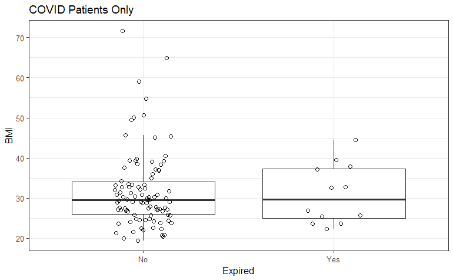

```r
ggplot(covid,
       aes(x = Expired,
           y = BMI)) +
  geom_boxplot(outlier.shape = "") +
  geom_point(aes(group = `Real ID`),
             shape = 21,
             size = 2,
             position = position_dodge(0.3)) +
  ggtitle("COVID Patients Only") +
  theme_bw()
```

### Death vs Critical Care

Significant

```r
addmargins(table(Death = covid$Expired,
                 CrCare = covid$`Critical Care`))
```

```
     CrCare
Death  No Yes Sum
  No   92   6  98
  Yes   5   7  12
  Sum  97  13 110
```

```r
chisq.test(covid$Expired,
           covid$`Critical Care`)
```

```
    Pearson's Chi-squared test with Yates' continuity correction

data:  covid$Expired and covid$`Critical Care`
X-squared = 23.179, df = 1, p-value = 0.000001476
```

```r
m3 <- glm(Expired ~ `Critical Care`,
          family = binomial,
          data = covid)
s3 <- summary(m3)

out3 <- data.table(Response = "Dead",
                   Comparison = c("ICU: Yes vs. No"),
                   OR = round(exp(s3$coefficients[-1, 1]),
                              2),
                   `95% C.I.L.B.` = exp(s3$coefficients[-1, 1] - 1.96*s3$coefficients[-1, 2]),
                   `95% C.I.U.B.` = exp(s3$coefficients[-1, 1] + 1.96*s3$coefficients[-1, 2]),
                   `p-Value` = ifelse(s3$coefficients[-1, 4] >= 0.001,
                                      round(s3$coefficients[-1, 4], 3),
                                      "<0.001"),
                   sign = ifelse(s3$coefficients[-1, 4] <= 0.05,
                                 ifelse(s3$coefficients[-1, 4] <= 0.01,
                                        "**",
                                        "*"), ""))

out3
```

| Response | Comparison | OR | 95% C.I.L.B. | 95% C.I.U.B. | p-Value | sign |
| --- | --- | --- | --- | --- | --- | --- |
| Dead | ICU: Yes vs. No | 21.47 | 5.220607 | 88.26901 | <0.001 | ** |

```r
m3 <- glm(Expired ~ `Critical Care`,
          family = binomial,
          data = nocovid)
s3 <- summary(m3)

out31 <- data.table(Response = "Dead",
                    Comparison = c("ICU: Yes vs. No"),
                    OR = round(exp(s3$coefficients[-1, 1]),
                               2),
                    `95% C.I.L.B.` = exp(s3$coefficients[-1, 1] - 1.96*s3$coefficients[-1, 2]),
                    `95% C.I.U.B.` = exp(s3$coefficients[-1, 1] + 1.96*s3$coefficients[-1, 2]),
                    `p-Value` = ifelse(s3$coefficients[-1, 4] >= 0.001,
                                       round(s3$coefficients[-1, 4], 3),
                                       "<0.001"),
                    sign = ifelse(s3$coefficients[-1, 4] <= 0.05,
                                  ifelse(s3$coefficients[-1, 4] <= 0.01,
                                         "**",
                                         "*"), ""))

out31
```

| Response | Comparison | OR | 95% C.I.L.B. | 95% C.I.U.B. | p-Value | sign |
| --- | --- | --- | --- | --- | --- | --- |
| Dead | ICU: Yes vs. No | 5.67 | 0.484238 | 66.31266 | 0.167 |  |

### Death vs. COVID | Diabetes

No significant difference.  
Model with interaction is worse.

```r
m2 <- glm(Expired ~ `Study Group` +
            AnyDM,
          family = binomial,
          data = dt1)
s2 <- summary(m2)

out2 <- data.table(Response = "Dead",
                   Comparison = c("COVID vs. No Covid",
                                  "Any DM vs. No DM"),
                   OR = round(exp(s2$coefficients[-1, 1]),
                              2),
                   `95% C.I.L.B.` = exp(s2$coefficients[-1, 1] - 1.96*s2$coefficients[-1, 2]),
                   `95% C.I.U.B.` = exp(s2$coefficients[-1, 1] + 1.96*s2$coefficients[-1, 2]),
                   `p-Value` = ifelse(s2$coefficients[-1, 4] >= 0.001,
                                      round(s2$coefficients[-1, 4], 3),
                                      "<0.001"),
                   sign = ifelse(s2$coefficients[-1, 4] <= 0.05,
                                 ifelse(s2$coefficients[-1, 4] <= 0.01,
                                        "**",
                                        "*"), ""))

out2
```

| Response | Comparison | OR | 95% C.I.L.B. | 95% C.I.U.B. | p-Value | sign |
| --- | --- | --- | --- | --- | --- | --- |
| Dead | COVID vs. No Covid | 3.11 | 0.8323130 | 11.653719 | 0.092 |  |
| Dead | Any DM vs. No DM | 1.83 | 0.6194279 | 5.425045 | 0.274 |  |

### Death vs COVID, adjusted for critical care

Both significant in additive model.

```r
m4 <- glm(Expired ~ `Study Group` + `Critical Care`,
          family = binomial,
          data = dt1)
s4 <- summary(m4)
ci4 <- confint(m4)
out4 <- data.table(Response = "Dead",
                   Comparison = c("COVID vs. No Covid",
                                  "ICU"),
                   OR = round(exp(s4$coefficients[-1, 1]),
                              2),
                   `95% C.I.L.B.` = exp(ci4[-1, 1]),
                   `95% C.I.U.B.` = exp(ci4[-1, 2]),
                   `p-Value` = ifelse(s4$coefficients[-1, 4] >= 0.001,
                                      round(s4$coefficients[-1, 4],
                                            3),
                                      "<0.001"),
                   sign = ifelse(s4$coefficients[-1, 4] <= 0.05,
                                 ifelse(s4$coefficients[-1, 4] <= 0.01,
                                        "**",
                                        "*"), ""))

out4
```

| Response | Comparison | OR | 95% C.I.L.B. | 95% C.I.U.B. | p-Value | sign |
| --- | --- | --- | --- | --- | --- | --- |
| Dead | COVID vs. No Covid | 6.79 | 1.731243 | 36.06632 | 0.012 | * |
| Dead | ICU | 16.31 | 4.768299 | 62.43100 | <0.001 | ** |

No significance in interaction model.

```r
m41 <- glm(Expired ~ `Study Group`*`Critical Care`,
           family = binomial,
           data = dt1)
summary(m41)
```

```
Call:
glm(formula = Expired ~ `Study Group` * `Critical Care`, family = binomial,
    data = dt1)

Coefficients:
                                      Estimate Std. Error z value  Pr(>|z|)
(Intercept)                             -3.932      1.010  -3.894 0.0000985 ***
`Study Group`COVID                       1.019      1.109   0.919     0.358
`Critical Care`Yes                       1.735      1.255   1.382     0.167
`Study Group`COVID:`Critical Care`Yes    1.332      1.448   0.920     0.358
---
Signif. codes:  0 ‘***’ 0.001 ‘**’ 0.01 ‘*’ 0.05 ‘.’ 0.1 ‘ ’ 1

(Dispersion parameter for binomial family taken to be 1)

    Null deviance: 103.607  on 181  degrees of freedom
Residual deviance:  80.222  on 178  degrees of freedom
AIC: 88.222

Number of Fisher Scoring iterations: 6
```

### Death vs COVID, adjusted for DM

No significance

```r
m5 <- glm(Expired ~ `Study Group` +
            AnyDM,
          family = binomial,
          data = dt1)
summary(m5)
```

```
Call:
glm(formula = Expired ~ `Study Group` + AnyDM, family = binomial,
    data = dt1)

Coefficients:
                   Estimate Std. Error z value    Pr(>|z|)
(Intercept)         -3.4552     0.6766  -5.107 0.000000327 ***
`Study Group`COVID   1.1360     0.6733   1.687      0.0915 .
AnyDM1               0.6060     0.5536   1.095      0.2736
---
Signif. codes:  0 ‘***’ 0.001 ‘**’ 0.01 ‘*’ 0.05 ‘.’ 0.1 ‘ ’ 1

(Dispersion parameter for binomial family taken to be 1)

    Null deviance: 103.607  on 181  degrees of freedom
Residual deviance:  99.578  on 179  degrees of freedom
AIC: 105.58

Number of Fisher Scoring iterations: 5
```

### Death vs COVID, adjusted

```r
m6 <- glm(Expired ~ `Study Group` +
            AnyDM +
            Age_Category +
            Sex +
            Race +
            BMI,
          family = binomial,
          data = dt1)
summary(m6)
```

```
Call:
glm(formula = Expired ~ `Study Group` + AnyDM + Age_Category +
    Sex + Race + BMI, family = binomial, data = dt1)

Coefficients:
                     Estimate Std. Error z value Pr(>|z|)
(Intercept)          -3.83621    1.99920  -1.919   0.0550 .
`Study Group`COVID    1.24680    0.73691   1.692   0.0907 .
AnyDM1                0.63127    0.61983   1.018   0.3085
Age_Category1        -0.63991    1.52331  -0.420   0.6744
Age_Category2         0.71858    1.35403   0.531   0.5956
Age_Category3         1.91051    1.26697   1.508   0.1316
Age_Category4         2.73225    1.34075   2.038   0.0416 *
SexFemale            -1.87148    0.86121  -2.173   0.0298 *
RaceBlack           -16.23056 2588.93016  -0.006   0.9950
RaceAsian             1.76647    0.85763   2.060   0.0394 *
RaceHispanic         -0.30837    1.18960  -0.259   0.7955
RaceOther           -15.24814 3429.98234  -0.004   0.9965
BMI                  -0.02669    0.04950  -0.539   0.5897
---
Signif. codes:  0 ‘***’ 0.001 ‘**’ 0.01 ‘*’ 0.05 ‘.’ 0.1 ‘ ’ 1

(Dispersion parameter for binomial family taken to be 1)

    Null deviance: 103.607  on 181  degrees of freedom
Residual deviance:  77.636  on 169  degrees of freedom
AIC: 103.64

Number of Fisher Scoring iterations: 18
```

### New variable: DM+Obesity

```r
chisq.test(dt1$AnyDM,
           dt1$Obese)
```

```
    Pearson's Chi-squared test with Yates' continuity correction

data:  dt1$AnyDM and dt1$Obese
X-squared = 0.82588, df = 1, p-value = 0.3635
```

## ICU

### ICU LOS

```r
summary(dt1$`ICU LOS`)
```

```
   Min. 1st Qu.  Median    Mean 3rd Qu.    Max.
  0.000   0.000   0.000   1.676   0.000  47.000
```

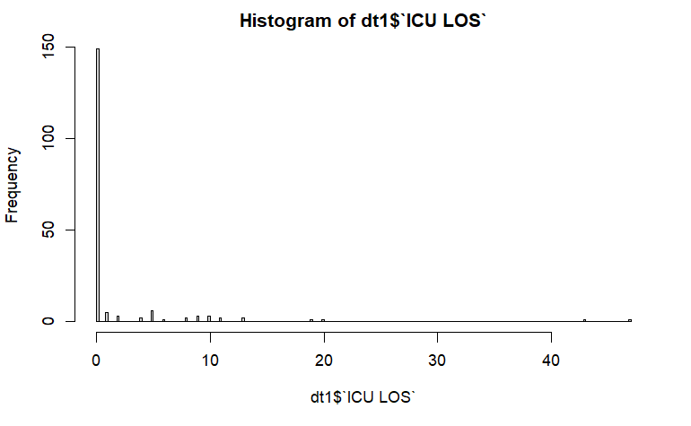

```r
hist(dt1$`ICU LOS`, 200)
```

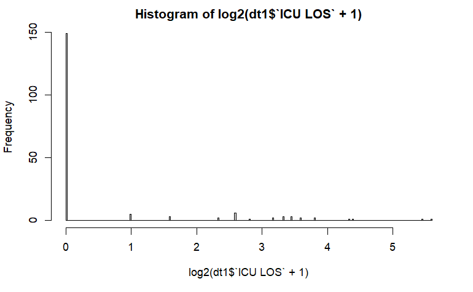

```r
hist(log2(dt1$`ICU LOS` + 1), 200)
```

```r
m7 <- lm(log2(`ICU LOS` + 1) ~ AnyDM +
           Age +
           Sex +
           Race +
           BMI +
           `Critical Care`,
         family = binomial,
         data = dt1)
summary(m7)
```

```
Call:
lm(formula = log2(`ICU LOS` + 1) ~ AnyDM + Age + Sex + Race +
    BMI + `Critical Care`, data = dt1, family = binomial)

Residuals:
     Min       1Q   Median       3Q      Max
-1.94991 -0.07183  0.00615  0.07659  2.72171

Coefficients:
                     Estimate Std. Error t value            Pr(>|t|)
(Intercept)        -0.2354350  0.2417876  -0.974               0.332
AnyDM1              0.0884018  0.0807911   1.094               0.275
Age                -0.0001559  0.0025336  -0.062               0.951
SexFemale          -0.0534853  0.0781348  -0.685               0.495
RaceBlack           0.1220359  0.1512242   0.807               0.421
RaceAsian          -0.0737254  0.1161456  -0.635               0.526
RaceHispanic       -0.0352396  0.1377389  -0.256               0.798
RaceOther           0.0839196  0.1863429   0.450               0.653
BMI                 0.0076527  0.0047331   1.617               0.108
`Critical Care`Yes  2.8699236  0.1019370  28.154 <0.0000000000000002 ***
---
Signif. codes:  0 ‘***’ 0.001 ‘**’ 0.01 ‘*’ 0.05 ‘.’ 0.1 ‘ ’ 1

Residual standard error: 0.5126 on 172 degrees of freedom
Multiple R-squared:  0.8298,    Adjusted R-squared:  0.8209
F-statistic: 93.19 on 9 and 172 DF,  p-value: < 0.00000000000000022
```

### Critical care

```r
m8 <- glm(`Critical Care` ~ AnyDM +
            Age +
            Sex +
            Race +
            BMI,
          family = binomial,
          data = droplevels(dt1))
summary(m8)
```

```
Call:
glm(formula = `Critical Care` ~ AnyDM + Age + Sex + Race + BMI,
    family = binomial, data = droplevels(dt1))

Coefficients:
             Estimate Std. Error z value Pr(>|z|)
(Intercept)  -2.18171    1.51251  -1.442   0.1492
AnyDM1        0.17243    0.42004   0.410   0.6814
Age           0.03538    0.01499   2.361   0.0182 *
SexFemale    -0.36469    0.42091  -0.866   0.3863
RaceBlack    -0.13887    0.85064  -0.163   0.8703
RaceAsian     0.29030    0.64121   0.453   0.6507
RaceHispanic  0.61687    0.65875   0.936   0.3491
RaceOther    -0.12312    1.15334  -0.107   0.9150
BMI          -0.05831    0.03300  -1.767   0.0773 .
---
Signif. codes:  0 ‘***’ 0.001 ‘**’ 0.01 ‘*’ 0.05 ‘.’ 0.1 ‘ ’ 1

(Dispersion parameter for binomial family taken to be 1)

    Null deviance: 172.31  on 181  degrees of freedom
Residual deviance: 158.98  on 173  degrees of freedom
AIC: 176.98

Number of Fisher Scoring iterations: 5
```

## WHO-OSCI

### Desease severity at baseline by WHO-OSCI

if <5 = mild  
if >= 5 = severe  
5 = very sick  
6 = intubated  
7 = ventilated  
if 8: dead

```r
covid$who_osci_d1_cat <- "Dead"
covid$who_osci_d1_cat[as.numeric(as.character(covid$`WHO-OSCI D1`)) < 8] <- "Severe"
covid$who_osci_d1_cat[as.numeric(as.character(covid$`WHO-OSCI D1`)) < 5] <- "Mild"

covid$who_osci_d1_cat <- factor(covid$who_osci_d1_cat,
                                levels = c("Mild",
                                           "Severe"))
summary(covid$who_osci_d1_cat)
```

```
  Mild Severe
    33     77
```

```r
addmargins(table("WHO-OSCI D1" = dt1$`WHO-OSCI D1`,
                 CC = dt1$`Critical Care`))
```

```
           CC
WHO-OSCI D1  No Yes Sum
        0     3   0   3
        1     0   0   0
        2     0   0   0
        3     8   0   8
        4    22   0  22
        5    59   5  64
        6     5   8  13
        7     0   0   0
        Sum  97  13 110
```

### WHO-OSCI over time

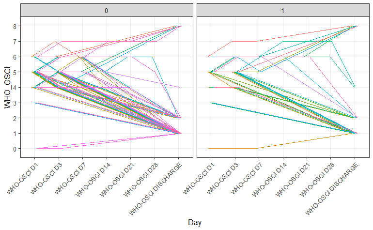

```r
tmp <- dt1[, c("Real ID",
               "Study Group",
               "AnyDM",
               "Expired",
               "WHO-OSCI D1",
               "WHO-OSCI D3",
               "WHO-OSCI D7",
               "WHO-OSCI D14",
               "WHO-OSCI D21",
               "WHO-OSCI D28",
               "WHO-OSCI DISCHARGE")]

tmp <- melt.data.table(tmp,
                       id.vars = c(1:4),
                       variable.name = "Day",
                       value.name = "WHO_OSCI")
tmp$Day <- factor(tmp$Day,
                  levels = unique(tmp$Day))

tmp <- tmp[!is.na(tmp$WHO_OSCI), ]
ggplot(tmp,
       aes(x = Day,
           y = WHO_OSCI,
           group = `Real ID`,
           color = `Real ID`)) +
  facet_wrap(~ AnyDM) +
  geom_line(position = position_dodge(0.3)) +
  theme_bw() +
  theme(legend.position = "none") +
  theme(axis.text.x = element_text(angle = 45,
                                   hjust = 1))
```

```r
table(dt1$`WHO-OSCI D1`,
      dt1$Expired)
```

```
    No Yes
  0  3   0
  1  0   0
  2  0   0
  3  8   0
  4 22   0
  5 58   6
  6  7   6
  7  0   0
```

### Table 2

```r
t2 <- dcast.data.table(`Real ID` ~ Day,
                       value.var = "WHO_OSCI",
                       data = tmp[Expired == "Yes", ])

write.csv(t2,
          file = "tmp/table2.csv",
          row.names = FALSE)

t2
```

| Real ID | WHO-OSCI D1 | WHO-OSCI D3 | WHO-OSCI D7 | WHO-OSCI D14 | WHO-OSCI D21 | WHO-OSCI D28 | WHO-OSCI DISCHARGE |
| --- | --- | --- | --- | --- | --- | --- | --- |
| 145303 | 6 | 7 | 7 | NA | NA | NA | 8 |
| 162341 | 6 | 6 | NA | NA | NA | NA | 8 |
| 457084 | 5 | 5 | 5 | NA | NA | NA | 8 |
| 545008 | 5 | 6 | 6 | 6 | 6 | 7 | 8 |
| 560874 | 5 | 5 | 5 | NA | NA | NA | 8 |
| 68601 | 5 | 6 | 6 | NA | NA | NA | 8 |
| 771982 | 5 | 4 | NA | NA | NA | NA | 8 |
| 778824 | 6 | 6 | 5 | NA | NA | NA | 8 |
| 8125410 | 6 | 6 | 6 | 7 | 7 | NA | 8 |
| 8133455 | 6 | 7 | 7 | 7 | 7 | 7 | 8 |

[output cut: 2 more lines]

```r
dt1[,
    .(N = .N,
      mu_los = mean(LOS),
      sem_los = sd(LOS)/sqrt(.N)),
    by = c("Study Group")]
```

| Study Group | N | mu_los | sem_los |
| --- | --- | --- | --- |
| COVID | 110 | 7.318182 | 0.8596149 |
| No COVID | 72 | 8.791667 | 1.0876921 |

```r
dt1[,
    .(N = .N,
      mu_los = mean(LOS),
      sem_los = sd(LOS)/sqrt(.N)),
    by = c("Expired")]
```

| Expired | N | mu_los | sem_los |
| --- | --- | --- | --- |
| No | 167 | 7.491018 | 0.6958641 |
| Yes | 15 | 12.466667 | 2.4277496 |

```r
dt1[,
    .(N = .N,
      mu_los = mean(LOS),
      sem_los = sd(LOS)/sqrt(.N)),
    by = c("Expired",
           "Study Group")]
```

| Expired | Study Group | N | mu_los | sem_los |
| --- | --- | --- | --- | --- |
| No | COVID | 98 | 6.642857 | 0.8767097 |
| Yes | COVID | 12 | 12.833333 | 2.9434914 |
| No | No COVID | 69 | 8.695652 | 1.1257856 |
| Yes | No COVID | 3 | 11.000000 | 3.7859389 |

```r
dt1[LOS > 1,
    .(N = .N,
      mu_los = mean(LOS),
      sem_los = sd(LOS)/sqrt(.N)),
    by = c("Expired",
           "Study Group")]
```

| Expired | Study Group | N | mu_los | sem_los |
| --- | --- | --- | --- | --- |
| No | COVID | 88 | 7.397727 | 0.9434839 |
| Yes | COVID | 12 | 12.833333 | 2.9434914 |
| No | No COVID | 59 | 10.101695 | 1.2255069 |
| Yes | No COVID | 3 | 11.000000 | 3.7859389 |

```r
dt1$LOS[dt1$`Real ID` == 771982]
```

# RNA-seq

https://bioconductor.org/packages/devel/bioc/vignettes/DESeq2/inst/doc/DESeq2.html

## Merge RNA-seq meta-data with clinical

```r
rnaseq_meta_clin <- merge(rnaseq_meta,
                          dt1[, c("Real ID",
                                  "Study Group",
                                  "Expired",
                                  "Critical Care",
                                  "Age",
                                  "Sex",
                                  "Race",
                                  "BMI",
                                  "AnyDM")],
                          by = "Real ID")
```

## Duplicated gene names

```r
dups <- dt_rna[gene_name %in% gene_name[duplicated(gene_name) == TRUE], ]
```

## Gene types

```r
addmargins(table(dt_rna$gene_biotype))
```

## Protein coding genes only

```r
dt_rna_cod <- dt_rna[gene_biotype == "protein_coding",]
```

### Duplicated coding genes

```r
dup_cod <- dt_rna_cod[gene_name %in% gene_name[duplicated(gene_name) == TRUE], ]
dup_cod_genes <- unique(dup_cod$gene_name)
dup_cod_genes
```

### Add counts for the same genes

```r
out <- list()
for (i in 1:length(dup_cod_genes)) {
  out[[i]] <- dup_cod[gene_name == dup_cod_genes[i], ]

  for (j in 11:ncol(dup_cod)) {
    out[[i]][, j] <- sum(out[[i]][, j, with = FALSE])
  }
  out[[i]] <- out[[i]][gene_length == max(gene_length), ][1, ]
}
out <- do.call("rbind",
               out)

out
```

### Delete duplicates and replace them with aggregated counts for those genes

```r
dt_rna_cod <- dt_rna_cod[!(gene_name %in% dup_cod_genes), ]

dt_rna_cod <- rbindlist(list(dt_rna_cod,
                             out))

length(unique(dt_rna_cod$gene_name))
nrow(dt_rna_cod)
```

### Prepare DESeq object

```r
names(rnaseq_meta_clin)[3] <- "Cohort"

ndx <- which(colnames(dt_rna_cod) %in% rnaseq_meta_clin$sample_names)
rnaseq_meta_clin$Cohort <- gsub(x = rnaseq_meta_clin$Cohort,
                                pattern = " ",
                                replacement = "_")
rnaseq_meta_clin$Cohort <- factor(rnaseq_meta_clin$Cohort,
                                  levels = c("No_COVID",
                                             "COVID"))
```

### DESeq: COVID/non-COVID

```r
tmp <- as.matrix(dt_rna_cod[, ndx, with = FALSE])
rownames(tmp) <- dt_rna_cod$gene_id

dds_cod <- DESeqDataSetFromMatrix(countData = tmp,
                                  colData = rnaseq_meta_clin,
                                  ~ Cohort)
```

#### Filter out genes with small number of hits

```r
# Number of samples with at least 10 hits in at least X samples
min_n_hits <- c(1, 5, 10, 20, 50)

l2 <- list()

for (j in 1:length(min_n_hits)) {

  l1 <- list()

  for (i in 1:length(ndx)) {

    l1[[i]] <- data.table(`Min N of hits per sample` = min_n_hits[j],
                          `N samples with min hits or more` = i,
                          `N genes` = sum(rowSums(counts(dds_cod) >= j) >= i))
  }
  l2[[j]] <- do.call("rbind",
                     l1)
}

ll <- do.call("rbind",
              l2)
ll$`Min N of hits per sample` <- factor(ll$`Min N of hits per sample`,
                                        levels = min_n_hits)
```

```r
ll$lw <- 0.5
ll$lw[ll$`Min N of hits per sample` == 10] <- 1.5

ggplot(ll,
       aes(x = `N samples with min hits or more`,
           y = `N genes`,
           group = `Min N of hits per sample`,
           color = `Min N of hits per sample`)) +
  geom_line(linewidth = ll$lw) +
  geom_vline(xintercept = 10,
             linetype = "dashed",
             color = "red") +
  scale_x_continuous(breaks = seq(0, 92, 5)) +
  theme_bw()
```

```r
keep <- rowSums(counts(dds_cod) >= 10) >= 10
sum(keep)

dds_cod <- dds_cod[keep, ]
```

#### Run DESeq

```r
deseq_cod <- DESeq(dds_cod)

# deseq <- DESeq(dds,
#                fitType = "glmGamPoi")

resultsNames(deseq_cod)
```

#### DESeq results

```r
res <- results(deseq_cod)
res[1:10, ]
rownames(res)[1:10]
```

```r
out <- data.table(gene_id = rownames(res),
                  baseMean = res$baseMean,
                  log2FoldChange = res$log2FoldChange,
                  log2FoldChangeSE = res$lfcSE,
                  stat = res$stat,
                  pvalue = res$pvalue,
                  padj = res$padj)

out <- merge(dt_rna_cod[, c("gene_name",
                            "gene_id")],
             out,
             by = "gene_id")

out <- out[!is.na(padj), ]

setorder(out,
         padj)


head(out)

write.csv(out,
          file = "tmp/deseq2_cod_covid_nocovid.CSV",
          row.names = FALSE)
```

```r
tmp5 <- out[abs(log2FoldChange) > 1 &
              padj < 0.05, ]
#
# tmp5_up <- out[log2FoldChange > 1 &
#               padj < 0.05, ]
#
# tmp5_down <- out[log2FoldChange < -1 &
#               padj < 0.05, ]
```

#### Calculate the mean expressions of the selected genes

```r
tmp <- dt_rna_cod[gene_name %in% tmp5$gene_name, ]
tmp <- melt.data.table(data = tmp,
                       id.vars = 1,
                       measure.vars = 11:ncol(tmp),
                       variable.name = "sample_names",
                       value.name = "Hits")

tmp <- merge(tmp,
             rnaseq_meta_clin,
             by = "sample_names")
```

```r
p1 <- ggplot(tmp,
             aes(x = `Study Group`,
                 y = log2(Hits + 1))) +
  facet_wrap(~ gene_name,
             scale = "free_y") +
  geom_boxplot(width = 0.3,
               outlier.shape = "") +
  geom_point(aes(fill = AnyDM,
                 group = sample_names),
             size = 2,
             shape = 21,
             alpha = 0.5,
             position = position_dodge(0.3)) +
  scale_y_continuous("Number of hits",
                     breaks = seq(from = 1,
                                  to = 20,
                                  by = 2),
                     labels = (2^seq(from = 1,
                                     to = 20,
                                     by = 2)) - 1) +
  scale_fill_discrete("Any DM",
                      breaks = c(0, 1),
                      labels = c("No",
                                 "Yes")) +
  ggtitle(paste(c("Genes significantly differentially expressed in COVID-19 vs non-COVID patients.",
                  "Difference of the means of log2[hits+1] > 1 and adjusted p-value < 0.05"),
                collapse = "\n"))+
  theme_bw() +
  theme(legend.position = "bottom")

tiff(filename = "tmp/fig1_sign_genes_cod.tiff",
     height = 10,
     width = 10,
     units = 'in',
     res = 600,
     compression = "lzw+p")
print(p1)
graphics.off()

p1
```

```r
p2 <- ggplot(tmp[gene_name == "IFI27", ],
             aes(x = `Study Group`,
                 y = log2(Hits + 1))) +
  geom_boxplot(width = 0.3,
               outlier.shape = "") +
  geom_point(aes(fill = Expired,
                 group = sample_names),
             size = 3,
             shape = 21,
             alpha = 0.8,
             position = position_dodge(0.3)) +
  scale_y_continuous("Number of hits",
                     breaks = seq(from = 1,
                                  to = 20,
                                  by = 2),
                     labels = (2^seq(from = 1,
                                     to = 20,
                                     by = 2)) - 1) +
  scale_fill_discrete("In-Hospital Death",
                      breaks = c(0, 1),
                      labels = c("No",
                                 "Yes")) +
  ggtitle(paste(c("IFI27 expression in COVID-19 vs non-COVID patients.",
                  "Difference of the means of log2[hits+1] > 1",
                  "and adjusted p-value < 0.05"),
                collapse = "\n")) +
  theme_bw() +
  theme(legend.position = "bottom")

p3 <- ggplot(tmp[gene_name == "IFI27", ],
             aes(x = `Study Group`,
                 y = log2(Hits + 1))) +
  geom_boxplot(width = 0.3,
               outlier.shape = "") +
  geom_point(aes(fill = `Critical Care`,
                 group = sample_names),
             size = 3,
             shape = 21,
             alpha = 0.8,
             position = position_dodge(0.3)) +
  scale_y_continuous("Number of hits",
                     breaks = seq(from = 1,
                                  to = 20,
                                  by = 2),
                     labels = (2^seq(from = 1,
                                     to = 20,
                                     by = 2)) - 1) +
  scale_fill_discrete("Critical Care",
                      breaks = c(0, 1),
                      labels = c("No",
                                 "Yes")) +
  ggtitle(paste(c("IFI27 expression in COVID-19 vs non-COVID patients.",
                  "Difference of the means of log2[hits+1] > 1",
                  "and adjusted p-value < 0.05"),
                collapse = "\n")) +
  theme_bw() +
  theme(legend.position = "bottom")

tiff(filename = "tmp/fig2_ifi27_covid_noncovid.tiff",
     height = 6,
     width = 9,
     units = 'in',
     res = 600,
     compression = "lzw+p")
grid.arrange(p2,
             p3,
             nrow = 1)
# grid.arrange(p2,
#              p3,
#              nrow = 1,
#              top = textGrob(paste(c("IFI27 expression in COVID-19 vs non-COVID patients.",
#                                     "Difference of the means of log2[hits+1] > 1",
#                                     "and adjusted p-value < 0.05"),
#                                   collapse = "\n"),
#                             gp = gpar(fontsize = 20,
#                                       font = 3)))
graphics.off()

grid.arrange(p2,
             p3,
             nrow = 1)
```

#### Table 3: COVID/non-COVID significant DEs

```r
# mu <- tmp[, .(mu = exp(mean(log(Hits + 1))) - 1,
#               med = median(Hits)),
#               by = list(gene_name,
#                         Cohort)]
# mu

med <- tmp[, .(med = median(Hits)),
           by = list(gene_name,
                     Cohort)]
med <- dcast.data.table(data = med,
                        gene_name ~ Cohort,
                        value.var = "med")
med

t3 <- data.table(gene_name = tmp5$gene_name,
                 `Log2 Fold Change` = round(tmp5$log2FoldChange, 2),
                 `SE of Log2 Fold Change` = round(tmp5$log2FoldChangeSE, 2),
                 `Adjusted p-Value` = round(tmp5$padj, 3))

t3 <- merge(med,
            t3,
            by = "gene_name")

names(t3)[1:3] <- c("Gene",
                    "Median hits in non-COVID",
                    "Median hits in COVID")

write.csv(t3,
          file = "tmp/t3.csv",
          row.names = FALSE)
t3
```

### DESeq: AnyDM/no DM

```r
tmp <- as.matrix(dt_rna_cod[, ndx, with = FALSE])
rownames(tmp) <- dt_rna_cod$gene_id

dds_cod_dm <- DESeqDataSetFromMatrix(countData = tmp,
                                     colData = rnaseq_meta_clin,
                                     ~ AnyDM)
```

#### Filter out genes with small number of hits

```r
keep <- rowSums(counts(dds_cod_dm) >= 10) >= 10
sum(keep)

dds_cod_dm <- dds_cod_dm[keep, ]
```

#### Run DESeq

```r
deseq_cod_dm <- DESeq(dds_cod_dm)

resultsNames(deseq_cod_dm)
```

#### DESeq results

```r
res_dm <- results(deseq_cod_dm)
res_dm[1:10, ]
rownames(res_dm)[1:10]
```

```r
out_dm <- data.table(gene_id = rownames(res_dm),
                     baseMean = res_dm$baseMean,
                     log2FoldChange = res_dm$log2FoldChange,
                     log2FoldChangeSE = res_dm$lfcSE,
                     stat = res_dm$stat,
                     pvalue = res_dm$pvalue,
                     padj = res_dm$padj)

out_dm <- merge(dt_rna_cod[, c("gene_name",
                               "gene_id")],
                out_dm,
                by = "gene_id")

out_dm <- out_dm[!is.na(padj), ]

setorder(out_dm,
         padj)


head(out_dm)

write.csv(out_dm,
          file = "tmp/deseq2_cod_dm.CSV",
          row.names = FALSE)
```

```r
tmp6 <- out_dm[abs(log2FoldChange) > 1 &
                 padj < 0.05, ]
```

#### Calculate the mean expressions of the selected genes

```r
tmp <- dt_rna_cod[gene_name %in% tmp6$gene_name, ]
tmp <- melt.data.table(data = tmp,
                       id.vars = 1,
                       measure.vars = 11:ncol(tmp),
                       variable.name = "sample_names",
                       value.name = "Hits")

tmp <- merge(tmp,
             rnaseq_meta_clin,
             by = "sample_names")
```

#### Table 3: DM/no DM significant DEs

```r
med <- tmp[, .(med = median(Hits)),
           by = list(gene_name,
                     Cohort)]
med <- dcast.data.table(data = med,
                        gene_name ~ Cohort,
                        value.var = "med")
med

t4 <- data.table(gene_name = tmp6$gene_name,
                 `Log2 Fold Change` = round(tmp6$log2FoldChange, 2),
                 `SE of Log2 Fold Change` = round(tmp6$log2FoldChangeSE, 2),
                 `Adjusted p-Value` = round(tmp6$padj, 3))

t4 <- merge(med,
            t4,
            by = "gene_name")

names(t4)[1:3] <- c("Gene",
                    "Median hits in non-COVID",
                    "Median hits in COVID")

write.csv(t4,
          file = "tmp/t4.csv",
          row.names = FALSE)
t4
```

```r
sum(t4$`Log2 Fold Change` > 0)
sum(t4$`Log2 Fold Change` < 0)
```

### DE in COVID and DM

```r
covid_and_dm <- t4$Gene[t4$Gene %in% t3$Gene]
covid_and_dm
```

```r
dt_f3 <- dt_rna_cod[gene_name %in% covid_and_dm, ]

dt_f3 <- melt.data.table(data = dt_f3,
                         id.vars = 1,
                         measure.vars = 11:ncol(dt_f3),
                         variable.name = "sample_names",
                         value.name = "Hits")
dt_f3 <- merge(dt_f3,
               rnaseq_meta_clin,
               by = "sample_names")
```

```r
p4 <- ggplot(dt_f3,
             aes(x = Cohort,
                 y = log2(Hits + 1))) +
  facet_wrap(~ gene_name,
             scale = "free_y",
             ncol = 1) +
  geom_boxplot(width = 0.3,
               outlier.shape = "") +
  geom_point(aes(fill = AnyDM,
                 group = sample_names),
             size = 2,
             shape = 21,
             alpha = 0.7,
             position = position_dodge(0.3)) +
  scale_x_discrete("COVID",
                   breaks = c("No_COVID",
                              "COVID"),
                   labels = c("No",
                              "Yes")) +
  scale_y_continuous("Number of hits",
                     breaks = seq(from = 1,
                                  to = 20,
                                  by = 2),
                     labels = (2^seq(from = 1,
                                     to = 20,
                                     by = 2)) - 1) +
  scale_fill_discrete("Any DM",
                      breaks = c(0, 1),
                      labels = c("No",
                                 "Yes")) +
  theme_bw() +
  theme(legend.position = "bottom")

p5 <- ggplot(dt_f3,
             aes(x = AnyDM,
                 y = log2(Hits + 1))) +
  facet_wrap(~ gene_name,
             scale = "free_y",
             ncol = 1) +
  geom_boxplot(width = 0.3,
               outlier.shape = "") +
  geom_point(aes(fill = Cohort,
                 group = sample_names),
             size = 2,
             shape = 21,
             alpha = 0.7,
             position = position_dodge(0.3)) +
  scale_x_discrete("Any DM",
                   breaks = c(0, 1),
                   labels = c("No",
                              "Yes")) +
  scale_y_continuous("Number of hits",
                     breaks = seq(from = 1,
                                  to = 20,
                                  by = 2),
                     labels = (2^seq(from = 1,
                                     to = 20,
                                     by = 2)) - 1) +
  scale_fill_discrete("COVID",
                      breaks = c("No_COVID",
                                 "COVID"),
                      labels = c("No",
                                 "Yes")) +
  theme_bw() +
  theme(legend.position = "bottom")

tiff(filename = "tmp/fig3_covid_dm.tiff",
     height = 10,
     width = 6,
     units = 'in',
     res = 600,
     compression = "lzw+p")
grid.arrange(p4,
             p5,
             nrow = 1)
graphics.off()

grid.arrange(p4,
             p5,
             nrow = 1)
```

### DESeq: AnyDM/no DM in COVID patients only

```r
samples_covid_only <- rnaseq_meta_clin$sample_names[rnaseq_meta_clin$Cohort == "COVID"]
ndx_covid_only <- which(colnames(dt_rna_cod) %in% samples_covid_only)

tmp <- as.matrix(dt_rna_cod[, ndx_covid_only, with = FALSE])
rownames(tmp) <- dt_rna_cod$gene_id

dds_cod_dm_covid_only <- DESeqDataSetFromMatrix(countData = tmp,
                                                colData = rnaseq_meta_clin[sample_names %in% samples_covid_only],
                                                ~ AnyDM)
```

#### Filter out genes with small number of hits

```r
keep <- rowSums(counts(dds_cod_dm_covid_only) >= 10) >= 10
sum(keep)

dds_cod_dm_covid_only <- dds_cod_dm_covid_only[keep, ]
```

#### Run DESeq

```r
deseq_cod_dm_covid_only <- DESeq(dds_cod_dm_covid_only)

resultsNames(deseq_cod_dm_covid_only)
```

#### DESeq results

```r
res_dm_covid_only <- results(deseq_cod_dm_covid_only)
res_dm_covid_only[1:10, ]
rownames(res_dm_covid_only)[1:10]
```

```r
out_dm_covid_only <- data.table(gene_id = rownames(res_dm_covid_only),
                                baseMean = res_dm_covid_only$baseMean,
                                log2FoldChange = res_dm_covid_only$log2FoldChange,
                                log2FoldChangeSE = res_dm_covid_only$lfcSE,
                                stat = res_dm_covid_only$stat,
                                pvalue = res_dm_covid_only$pvalue,
                                padj = res_dm_covid_only$padj)

out_dm_covid_only <- merge(dt_rna_cod[, c("gene_name",
                                          "gene_id")],
                           out_dm_covid_only,
                           by = "gene_id")

out_dm_covid_only <- out_dm_covid_only[!is.na(padj), ]

setorder(out_dm_covid_only,
         padj)


head(out_dm_covid_only)

write.csv(out_dm_covid_only,
          file = "tmp/deseq2_cod_dm_covid_only.CSV",
          row.names = FALSE)
```

```r
tmp7 <- out_dm_covid_only[abs(log2FoldChange) > 1 &
                            padj < 0.05, ]
```

#### Calculate the mean expressions of the selected genes

```r
tmp <- dt_rna_cod[gene_name %in% tmp7$gene_name, ]
tmp <- melt.data.table(data = tmp,
                       id.vars = 1,
                       measure.vars = 11:ncol(tmp),
                       variable.name = "sample_names",
                       value.name = "Hits")

tmp <- merge(tmp,
             rnaseq_meta_clin,
             by = "sample_names")
```

#### Table 3: DM/no DM significant DEs

```r
# med <- tmp[, .(med = median(Hits)),
#            by = list(gene_name,
#                      Cohort)]
# med <- dcast.data.table(data = med,
#                         gene_name ~ Cohort,
#                         value.var = "med")
# med
#
# t4 <- data.table(gene_name = tmp6$gene_name,
#                  `Log2 Fold Change` = round(tmp6$log2FoldChange, 2),
#                  `SE of Log2 Fold Change` = round(tmp6$log2FoldChangeSE, 2),
#                  `Adjusted p-Value` = round(tmp6$padj, 3))
#
# t4 <- merge(med,
#             t4,
#             by = "gene_name")
#
# names(t4)[1:3] <- c("Gene",
#                     "Median hits in non-COVID",
#                     "Median hits in COVID")
#
# write.csv(t4,
#           file = "tmp/t4.csv",
#           row.names = FALSE)
# t4
```

```r
# sum(t4$`Log2 Fold Change` > 0)
# sum(t4$`Log2 Fold Change` < 0)
```